# **Part A: Convolutional Neural Network**

### Baseline Model 4 Creation (Custom AlexNet Template)

Below is how alex net look like

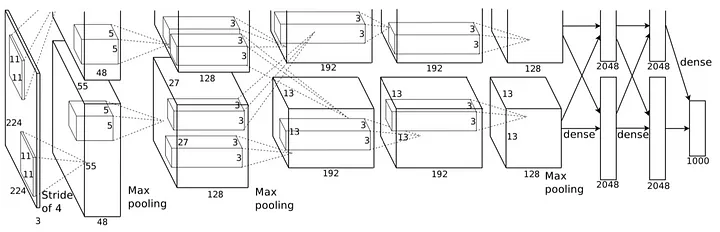

**AlexNet: Developed by Universit of Toronto**

**My Implementation**

- Suited for one colour channel
- Change in the number of strides from 4 to 2
- Change in second layer size
- Batch Normalisation was added

```python
def alexNet(optimizer='adam', name='AlexNet_Baseline'):
    model = Sequential(name=name)

    # Input Layer
    model.add(Input(shape=(31, 31, 1)))

    # First convolutional Block
    model.add(Conv2D(filters=96, kernel_size=(3,3), strides=(2,2), activation='relu'))
    model.add(MaxPooling2D(pool_size=(2,2), strides=(2,2)))
    model.add(BatchNormalization())

    # Second convolutional Block
    model.add(Conv2D(filters=256, kernel_size=(3,3), padding="same", activation='relu'))
    model.add(MaxPooling2D(pool_size=(2,2), strides=(2,2)))
    model.add(BatchNormalization())

    # two consecutive convolutional Block
    model.add(Conv2D(filters=512, kernel_size=(2,2), padding="same", activation='relu'))
    model.add(Conv2D(filters=512, kernel_size=(2,2), padding="same", activation='relu'))
    model.add(MaxPooling2D(pool_size=(2,2), strides=(2,2)))
    model.add(BatchNormalization())

    # Flatten Layer
    model.add(Flatten())

    # Fully connected layers
    model.add(Dense(units=4096, activation='relu'))
    model.add(Dropout(0.5))
    model.add(Dense(units=4096, activation='relu'))
    model.add(Dropout(0.5))
    model.add(Dense(units=15, activation='softmax'))

    # Compile the model
    optimizer = 'adam'
    model.compile(optimizer = 'adam', loss='categorical_crossentropy', metrics=['accuracy'])
    model.summary()

    return model
```

#### Running the model

```python
alexnet = alexNet()
results_alex, fig_alex = evaluator.model_evaluate( train_ds, val_ds , alexnet, base_hparams)
```

```
Model: "AlexNet_Baseline"
_________________________________________________________________
 Layer (type)                Output Shape              Param #
=================================================================
 conv2d (Conv2D)             (None, 15, 15, 96)        960

 max_pooling2d (MaxPooling2D  (None, 7, 7, 96)         0
 )

 batch_normalization (BatchN  (None, 7, 7, 96)         384
 ormalization)

 conv2d_1 (Conv2D)           (None, 7, 7, 256)         221440

 max_pooling2d_1 (MaxPooling  (None, 3, 3, 256)        0
 2D)

 batch_normalization_1 (Batc  (None, 3, 3, 256)        1024
 hNormalization)

 conv2d_2 (Conv2D)           (None, 3, 3, 512)         524800

 conv2d_3 (Conv2D)           (None, 3, 3, 512)         1049088

 max_pooling2d_2 (MaxPooling  (None, 1, 1, 512)        0
 2D)

 batch_normalization_2 (Batc  (None, 1, 1, 512)        2048
 hNormalization)

 flatten (Flatten)           (None, 512)               0

 dense (Dense)               (None, 4096)              2101248

 dropout (Dropout)           (None, 4096)              0

 dense_1 (Dense)             (None, 4096)              16781312

 dropout_1 (Dropout)         (None, 4096)              0

 dense_2 (Dense)             (None, 15)                61455

=================================================================
Total params: 20,743,759
Trainable params: 20,742,031
Non-trainable params: 1,728
_________________________________________________________________
```

- This is to check for overfitting
- And also how the model performs with respect to each classes

#### Analysing the graph

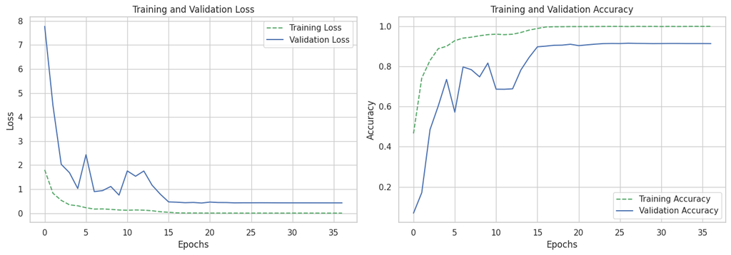

```python
fig_alex()
```

```python
pd.Series(results_alex)
```

```
Model Name    AlexNet_Baseline
Epochs                      37
Batch Size                 128
Train Loss            0.003449
Test Loss              0.43268
Train Acc             0.999114
Test Acc                 0.916
dtype: object
```

*Things Observed*

- Training and Validation loss  
 - For the training loss, it starts relatively high and drops quickly and continues to decrease steadily as the epochs increases  
 - For the validation loss, similar patterns occur with the epoch increasing with small spikes  
- Training and Validation accuracy  
 - For the training accuracy, it increases sharply at the beginning and continues to increase gradually, indicates effective lerarning  
 - For the validation accuracy, similar pattern is seen but with a lower accuracy here and noticeable downward spikes which similarly could suggest overfitting